# SPARK: Physiology-informed inference of latent cardiac autonomic dynamics from RR intervals

Authors

Affiliations

Matías Castillo-Aguilar

Universidad de Magallanes

Noah Beelders

Ludwig-Maximilians-Universität München

Cristian Núñez-Espinosa

Universidad de Magallanes

Published

November 17, 2026

Code Links

Model (R script)

**Highlights**

- RR alone may leave vagal-like and sympathetic-like drives ambiguous
- A phase-domain state-space model filters irregular RR intervals in continuous time
- Physiological priors and a spectral anchor restrict the set of latent solutions
- Atropine removes most vagal-like variability; propranolol alone does not
- How change is split between the two drives remains conditional on the anchor

**Abstract**

Heart rate variability (HRV) is widely used to assess cardiac autonomic regulation, but spectral indices cannot separate overlapping vagal and sympathetic contributions and require stationary windows. We propose SPARK (Stochastic Phase-domain Autonomic Reconstruction Kinetics), a state-space model in which fast (vagal-like) and slow (sympathetic-like) latent drives modulate an integrate-and-fire pacemaker. Conditioning on each beat-to-beat (RR) interval yields exact continuous-time Kalman filtering, tracking both drives beat by beat, with uncertainty, without interpolation or windowing. Because RR alone does not determine this decomposition, time-scale priors, a kinetic ordering and a spectral anchor constrain it, reducing multi-start solutions from a median of 23.5 to 1.0 and single-drive collapse from 75% to 4% of fits. We evaluated SPARK on 313 recordings from three cohorts and on public pharmacological-blockade data, where atropine reduced vagal-like variability to 0.16 of saline in 7 volunteers, whereas propranolol did not (1.42). During head-up tilt, the vagal-like state fell and the sympathetic-like state rose in 10 of 10 recordings; in 263 exercise recordings, median recovery times were 42 s (vagal-like) and 341 s (sympathetic-like); and in 40 young and older adults, latent summaries differed by age and were only partly predicted by conventional HRV metrics (median leave-one-out $R^2$ = 0.42). The fit diagnostics showed residual structure in most recordings; the slow drive also fell under atropine and is defined by its time scale, not sympathetic specificity; and the split between drives depends on the spectral anchor. SPARK is an open-source, beat-resolved tool for autonomic analysis in non-stationary protocols.

**Keywords**: Heart rate variability; State-space model; Kalman filter; Identifiability; Autonomic nervous system; Integrate-and-fire; Pharmacological blockade

# 1 Introduction

Cardiac autonomic regulation acts on several time scales. The sinoatrial node translates continuous efferent traffic into discrete beats: acetylcholine slows pacemaker firing within seconds, whereas norepinephrine accelerates it over tens of seconds [1–4]. Postural change or exercise therefore elicits time-resolved responses, namely vagal withdrawal, delayed sympathetic engagement and recovery, whose time courses are of physiological interest [5]. Microneurography measures sympathetic nerve activity directly but is invasive, and the spread of wearable electrocardiographic and photoplethysmographic sensors makes the beat-to-beat (RR) interval series the most accessible observable of this regulation [6]. RR, however, reflects the integrated influence of several processes rather than the activity of either branch [3], so recovering the latent dynamics is a problem of inference from an indirect observable [5,7].

Heart rate variability (HRV) analysis summarizes RR with time-domain statistics and spectral measures [5,8–10]. These descriptors are robust but quantify the output of the system rather than its latent state. From a signal-processing standpoint, three properties of RR limit them: the series is sampled irregularly, at the beats themselves; it is non-stationary during the transients of interest, which violates the assumptions of window-based spectral partitioning [5,11]; and its low-frequency band mixes sympathetic, vagal and baroreflex influences [8,12]. Generative alternatives model the pacemaker, from multiscale biophysical simulations [3,13] to integrate-and-fire oscillators in which a phase accumulates at a rate set by autonomic inputs and a beat occurs when it reaches a threshold [14]. For a drift–diffusion phase, intervals follow an inverse Gaussian distribution [15,16], and embedding this first-passage mechanism in a state-space model is usually handled by local linearization, sigma-point filtering or Euler–Maruyama discretization [7,17,18], approximations that can distort the continuous-time dynamics across irregular intervals [7]. Deep-learning models, although effective for pattern recognition, typically do not yield latent variables with explicit physiological meaning.

A second difficulty is identification. If RR is the outcome of a vagal-like process, a sympathetic-like process and observation noise, different combinations of time scales, amplitudes and noise can generate similar interval series [19]. Unconstrained maximum-likelihood estimation can then produce likelihood ridges and solutions in which one process absorbs all variability, so a good fit to RR is necessary but not sufficient evidence of a meaningful decomposition. We therefore treat independent physiological information not as a device to improve fit but as part of the identification structure that defines which solutions are admissible: the characteristic time scales and ordering of vagal and sympathetic effector kinetics [2,20], and the distribution of their modulation across frequency established by pharmacological blockade [21–23]. How far these assumptions shape the inferred trajectories should be measured, not assumed.

We implement this strategy in SPARK (Stochastic Phase-domain Autonomic Reconstruction Kinetics). Its components are established, namely Ornstein–Uhlenbeck processes [24], integrate-and-fire pacing [14], Kalman filtering [25] and spectral partitions of HRV [21]; the contribution is their combination in three parts. First, a phase-domain conditioning: each recorded interval is treated as a fixed observation window, and a terminal-threshold condition, which approximates first passage closely in the high-drift, low-noise regime of the sinoatrial node [26], makes the measurement equation linear and Gaussian in the time-integrals of the drives [27]. The Kalman filter is then exact, and the transitions across irregular intervals are computed analytically, without discretization. Second, an explicit identification structure, in which time-scale priors, a kinetic ordering and a wavelet-derived spectral anchor define the admissible solutions. Third, a systematic assessment of how far the decomposition is determined by the data and how far by these assumptions, through multi-start identifiability analyses, simulations with known truth and sensitivity analyses, together with an external test against pharmacological blockade and muscle sympathetic nerve activity. To our knowledge this combination has not been applied to RR-interval inference before. The method is available as an R engine and as a browser application that processes recordings locally.

We asked whether RR alone leaves the decomposition under-determined and whether physiological information reduces this ambiguity; whether the states change in the expected direction during orthostatic tilt; how they differ across healthy aging; whether they characterize adaptation and recovery during exercise; and whether they respond to autonomic blockade, and follow sympathetic nerve activity, as their labels imply. Conventional HRV measures and the independent measurements available in subsets of the recordings (tilt angle, arterial pressure, respiration, drug condition and nerve activity) are comparators, not model inputs, and the latent states are reconstructions conditional on the stated assumptions, not measurements of neural activity.

# 2 Methods

Derivations, algorithmic details and the extended justification of the modeling choices are in the supplementary material (section “Extended methods and discussion”); the configuration used in every analysis is stored with the results.

## 2.1 Conceptual model

SPARK represents the sinoatrial node as an integrate-and-fire pacemaker whose drift is modulated by two latent drives. Between two consecutive beats at times $t_{k-1}$ and $t_k$, starting from $\phi(t_{k-1}) = 0$, the sinoatrial phase $\phi$ evolves as a drift–diffusion process,

$$d\phi(t) = \nu(t)\,dt + \sigma_z\,dW(t), \qquad \nu(t) = \nu_0 - x_p(t) + x_s(t), \qquad t \in (t_{k-1}, t_k],$$

where $W(t)$ is a standard Wiener process; a beat occurs the first time $\phi$ reaches a normalized threshold of $1$ [14], after which $\phi$ is reset to zero. The drift $\nu(t)$ is the instantaneous pacing rate (Hz), $\nu_0$ the baseline rate, $\sigma_z$ the diffusion coefficient of threshold-level noise, and $x_p(t)$ and $x_s(t)$ the parasympathetic-like and sympathetic-like drives (Hz, deviations from their homeostatic baseline), hereafter the vagal and sympathetic drives for brevity. These labels denote model components distinguished by their kinetics and spectral allocation, not measured neural activity.

## 2.2 Latent autonomic dynamics

The drives are independent, mean-reverting Ornstein–Uhlenbeck (OU) processes [24]:

$$\begin{aligned}
dx_p(t) &= -\kappa_p x_p(t)\,dt + \sigma_p\,dW_p(t),\\
dx_s(t) &= -\kappa_s x_s(t)\,dt + \sigma_s\,dW_s(t),
\end{aligned}$$

where $\kappa_p$ and $\kappa_s$ are clearance rates (s$^{-1}$) with e-folding times $\tau_p = 1/\kappa_p$ and $\tau_s = 1/\kappa_s$. The diffusion coefficients are parameterized through the stationary variances, $\sigma_b = \sqrt{2\kappa_b V_b}$, with $V_s = \sigma^2_{sys}$ and $V_p = \lambda_P\,\sigma^2_{sys}$, so that $\lambda_P = V_p/V_s$ is the relative vagal variance; the global scale $\sigma^2_{sys}$ leaves the Kalman gain unchanged and is estimated analytically. The state is augmented with the running integrals of the drives, $dI_p = x_p\,dt$ and $dI_s = x_s\,dt$, giving $\tilde{X}(t) = [x_p, x_s, I_p, I_s]^\top$ and $d\tilde{X} = A\,\tilde{X}\,dt + G\,dW$ with constant matrices $A$ and $G$. The transition over any observed interval $\Delta t_k$ is the matrix exponential $\Phi_k = \exp(A\,\Delta t_k)$, with a closed-form process covariance (supplementary sections “Matrix exponential” and “Estimation algorithm”).

## 2.3 Observation model: phase-domain inversion

Under strict first passage, the interval $T = \inf\{t > 0 : \phi(t) \ge 1\}$ is inverse Gaussian for a constant drift [15], and a time-varying drift makes the state-space problem nonlinear [7,17]. We instead condition on the observed interval and impose that the phase accumulated over $[t_{k-1}, t_k]$ equals one,

$$1 = \nu_0\,\Delta t_k - \int_{t_{k-1}}^{t_k} x_p(t)\,dt + \int_{t_{k-1}}^{t_k} x_s(t)\,dt + \eta_k ,$$

where $\eta_k$ is Gaussian threshold-level noise with variance $\sigma_z^2\,\Delta t_k$ and $\sigma_z^2 = \sigma^2_{sys}\lambda_R$. This terminal-threshold condition drops the requirement that $\phi$ stay below 1 within the interval, which is accurate when the drift is large relative to the noise (an explicit bound is given in the supplementary section “Asymptotic convergence”). In the augmented state the observation is linear,

$$1 - \nu_0\,\Delta t_k = H\,\tilde{X}_k + \eta_k, \qquad H = [0,\ 0,\ -1,\ 1],$$

so the Kalman recursions are exact. After each measurement update the integral states are reset to zero while $x_p$ and $x_s$ continue to evolve, which represents the restart of phase accumulation at each beat while preserving the memory of the drives across beats. To limit the influence of ectopic beats and detection artifacts, the noise variance at each beat is inflated by a multiplier that grows with the largest relative change between adjacent intervals (supplementary section “Extended methods and discussion”); recordings with substantial non-sinus activity are outside the intended scope.

## 2.4 Model assumptions and identification structure

The physiological information that restricts the admissible solutions is listed in Table 1. These specifications are model assumptions informed by external evidence; they are not estimated from the present data, and their influence is evaluated by the identifiability analyses below.

Table 1: Components of the identification structure

| Component | Form | Rationale | Default setting |
| --- | --- | --- | --- |
| Positivity and kinetic ordering | $\kappa_s = e^{\theta_1}$, $\kappa_p = \kappa_s + e^{\theta_2}$ | Positive rates; vagal kinetics faster than sympathetic | Structural |
| Time-scale priors | Log-normal on $\tau_p$ and $\tau_s$ | Rapid vagal and slow sympathetic effector kinetics | 95% intervals: $\tau_p$ [3, 6] s; $\tau_s$ [100, 300] s |
| Separation prior | Beta on $U = (\kappa_p - \kappa_s)/(\kappa_p + \kappa_s)$ | Discourages collapse of the two time scales | Mode at $\kappa_p/\kappa_s = 20$; weight 10 |
| Spectral anchor | $\lambda_P$ fixed from partitioned wavelet energy | Allocates variance between branches by frequency | Crossover 0.10 Hz; band 0.04–0.40 Hz; vagal floor fraction 0.25 |
| Timing-jitter prior | Log-normal on equivalent RR timing jitter | Limits absorption of autonomic variance by the noise term | 95% interval [0.5, 20] ms |

The ordering $\kappa_p > \kappa_s$ removes label switching, that is, a solution in which the fast and the slow process exchange roles. The time-scale priors reflect rapid vagal and slow sympathetic effector kinetics [2,20,22,28] and are fixed across recordings. The ratio $\lambda_P$ is a deterministic function of the global wavelet spectrum of heart rate [29,30], partitioned into vagal and sympathetic energy with logistic frequency weights that encode pharmacological-blockade evidence [21–23,31,32]. Because it is computed from the series being fitted, $\lambda_P$ is data-informed, and equating the ratio of spectral energies with the ratio of latent variances is an approximation (supplementary section “Spectral anchoring”). The jitter prior, which spans the range expected for electrocardiographic and photoplethysmographic acquisition, limits the extent to which the noise term can absorb autonomic variability.

## 2.5 Inference and uncertainty

The Kalman recursion, with the Joseph form of the covariance update, processes the intervals sequentially. The baseline $\nu_0$ and the scale $\sigma^2_{sys}$ are profiled out analytically by generalized least squares, using two filters that share one Kalman gain. The remaining parameters $\theta = (\ln\kappa_s,\ \ln(\kappa_p - \kappa_s),\ \ln\lambda_R)$ are estimated by maximum a posteriori (MAP) estimation: the negative profiled log-likelihood plus the negative log-prior terms of Table 1 is minimized with the Broyden–Fletcher–Goldfarb–Shanno (BFGS) algorithm from three starting points, keeping the best run. States are then estimated by forward filtering conditional on the recording-level estimates; because parameter estimation and the spectral anchor use the whole recording, the overall procedure is retrospective rather than strictly causal. The state intervals are conditional on the MAP parameters, and standard errors of $\kappa_p$, $\kappa_s$ and $\lambda_R$ come from the numerical Hessian and the delta method (supplementary section “Estimation algorithm”). The model was implemented in R, and a browser implementation with the same specification is available for single recordings (see Code availability).

## 2.6 Model diagnostics

Filtered tracking accuracy is quantified by the mean absolute percentage error (MAPE) and the root mean square error (RMSE) between the observed and the implied RR; these are in-sample measures, not prediction errors. If the model is adequate, the standardized innovations $z_k$ are independent standard normal variates, so their probability integral transform $\Phi(z_k)$ is uniform on $(0, 1)$. This was tested with the Kolmogorov–Smirnov (KS) distance $D$ against the approximate critical value $1.36/\sqrt{N}$, whose behavior under a correctly specified model was examined by simulation, and serial dependence with the partial autocorrelation function (PACF) of $z_k$ over 40 lags (supplementary section “Goodness-of-fit diagnostic”).

## 2.7 Identifiability analyses

Four nested specifications were compared (Table 2). All keep the structural constraints of Table 1, and $M_3$, which combines all the physiological information, is used in every other analysis. In $M_0$ and $M_1$, $\lambda_P$ is a free parameter; in $M_2$ and $M_3$ it is fixed by the spectral anchor.

Table 2: Model specifications used in the identifiability analyses

| Specification | Time-scale and separation priors | Spectral anchor ($\lambda_P$ fixed) | Timing-jitter prior |
| --- | --- | --- | --- |
| $M_0$ (RR only) | no | no | no |
| $M_1$ (RR + time-scale constraints) | yes | no | no |
| $M_2$ (RR + spectral evidence) | no | yes | no |
| $M_3$ (combined) | yes | yes | yes |

Each specification was fitted from the same 100 dispersed starting points in a deterministic subset of up to 100 recordings per dataset. For each recording and specification we computed the number of *distinct solutions*; the *near-equivalent fits* (profiled log-likelihood within 2 units of the best) and the dispersion of $\ln\tau_p$, $\ln\tau_s$ and of the reconstructed trajectories among them; the *share of $x_p$ variance* and the proportion of fits in which one process absorbed essentially all variability (share below 0.05 or above 0.95; *one-process collapse*); the proportion of fits inside the 95% prior intervals; and the fit to RR (definitions in the supplementary section “Identifiability and sensitivity analyses: details”). Because the priors alter the objective, specifications are compared on the profiled log-likelihood and RR error, not on the posterior objective. In addition, profile surfaces of the objective were computed over a $100 \times 100$ grid of $(\tau_p, \tau_s)$; synthetic series with known drives were fitted in four scenarios (true time scales inside or outside the priors, vagal- or sympathetic-dominant variance); each hyperparameter was varied and each prior component removed in turn; and, to locate the boundary of identifiability, recordings were simulated over the time-scale ratio $\tau_s/\tau_p$ (with $\tau_p$ = 4 s), the variance ratio $\lambda_P$ and the recording length (5, 10 and 30 min) (supplementary section “Identifiability boundary”).

## 2.8 Data, preprocessing and event definition

*Data and cleaning.* RR intervals were derived from the electrocardiogram (ECG; a Polar H10 chest strap in the exercise cohort), with blood pressure, respiration (Fantasia database) or the tilt angle (Physiologic Response to Changes in Posture, PRCP, database) when available; the model itself uses only RR. RR intervals and covariates were cleaned with an adaptive running-median gate, chosen on simulated series with injected artifacts because it altered about 0.2% of artifact-free beats while correcting about 99.7% of artifacts (supplementary section “Data preparation and its checks”).

*Participants.* The PRCP database contains ten healthy adults, without reported age or sex. The Fantasia database contains 20 young (21–34 years) and 20 older (68–85 years) healthy adults, with equal numbers of women and men in each group as reported by the database. The exercise cohort consists of community-dwelling adults aged 60 years or older from the Magallanes region of Chile, whose sample is described in the original study [33]; 263 recordings were analyzed, and the recordings carry no subject characteristics. The blockade dataset comprises seven healthy volunteers, six of them men, aged 29.4 ± 2.3 years (mean ± SEM) [34].

*Events.* Each tilt and stand-up of the PRCP protocol is analyzed against its own baseline. Onsets came from the tilt-angle signal or the protocol annotations and otherwise, as in the exercise recordings, from piecewise-constant segmentation of heart rate; such events are detected from the modeled RR series, so timing relative to them is not independent evidence about the states (supplementary section “Event detection”).

## 2.9 Validation framework: orthostatic perturbation

The first biological test uses the PRCP tilt-table recordings [35]. The expected responses are a fast reduction of the vagal drive after tilt onset and a slower, sustained increase of the sympathetic drive; such a test can show that the components behave coherently, not that they are the autonomic branches. Each maneuver was analyzed against its own baseline (60 to 180 s, beginning 120 s after the previous maneuver returned) and a 120-s recovery window. We computed (i) the change in the mean of each state, standardized by its baseline standard deviation (SD); (ii) whether each change had the expected sign; and (iii) a step-response fit, $x(t) = x_0 + D\,[1 - e^{-(t-t_0)/\tau}]$ for $t \ge t_0$, giving the latency, the time constant and the onset lag $t_{0,s} - t_{0,p}$. Between-recording summaries used the median over the tilts of each recording. As a negative control, the same contrast was computed between the two halves of each resting baseline (exact 95% intervals; paired signed-rank test of the absolute standardized changes). Secondary analyses (comparison with a continuous wavelet transform, CWT, moving spectrum; the arterial-pressure response; the dose–response over tilt angle; the responses by kind of maneuver) are in the supplementary section “Secondary analyses of the perturbation”.

## 2.10 Generalization: aging

Resting recordings of the Fantasia database [36] were analyzed in a fixed window (600 s starting at 600 s of the recording), with group membership as the only subject characteristic. The latent summaries were $\nu_0$, $\tau_p$, $\tau_s$, $\ln(\kappa_p/\kappa_s)$, $\lambda_P$, $\hat\sigma^2_{sys}$, the equivalent timing jitter, the SD of each state, their ratio and the share of $x_p$ variance. Group differences (older minus young) were summarized by the Hodges–Lehmann shift, the Wilcoxon rank-sum test and Cliff’s $\delta$ with a bootstrap interval, with Benjamini–Hochberg control within each family of variables (latent and conventional HRV); with the group sizes available, all tests are exploratory. Stability was assessed by refitting two non-overlapping windows of each recording, with the intraclass correlation coefficient (ICC(3,1)) of the log values. To examine how far the time constants are set by their priors, both windows were also refitted with weak priors (95% intervals 0.5–60 s and 10–2000 s) and with empirical-Bayes priors estimated on the other half of the subjects (supplementary section “Partial pooling of the time constants”).

## 2.11 Exercise and recovery

The exercise recordings follow a two-minute step test with a rest–exercise–rest protocol [33]; each is fitted with time-invariant kinetics, so the non-stationary response is carried by the filtered states. The rest level of each state is its mean and SD from 20 s after the start to 5 s before the detected onset; the exercise response is the difference between the mean over the last 15 s of exercise and the rest level; and the path in the $(x_p, x_s)$ plane, with the states $u$ and $v$ in rest-SD units, is summarized by its length, the area it encloses and its maximum quadratic energy $E = (u^2 + v^2)/2$, descriptive measures introduced for this representation. Recovery times used the combination of four candidate definitions and three end-of-exercise rules that scored best on simulated recordings with known recovery constants, with right-censoring and Kaplan–Meier medians (supplementary section “Recovery-time benchmark”).

*Perturbation-response descriptors.* As a complement that uses both states and their uncertainty, we computed the descriptors proposed for latent autonomic trajectories [37]: the largest distance from the resting region during the perturbation, the time after its end from which the state stays within that region for 15 s, the probability of such a return within a horizon, and whether a second-stage hidden Markov model places the end of the horizon in a regime other than rest. Distances are in units of the stationary SDs of $M_3$ refitted to the resting beats alone, the tolerance is the 0.999 quantile of the stationary distance, and uncertainty comes from paths drawn from the filtered distributions; their recovery was first checked on simulated recordings with known states (supplementary section “Perturbation-response descriptors”).

## 2.12 Pharmacological blockade and sympathetic nerve activity

To test the labels of the two drives against an external manipulation, we used a public dataset in which seven healthy volunteers were studied supine with saline, atropine (0.04 mg/kg), atropine followed by propranolol (0.2 mg/kg; double blockade) and, on a second day, propranolol alone, each condition with 5 min of spontaneous and 5 min of 0.25-Hz paced breathing, and with simultaneous ECG and integrated muscle sympathetic nerve activity (MSNA) [34,38]. $M_3$ was fitted, unchanged, to every segment, and the stationary SDs of the two drives under each drug were expressed as ratios to saline of the same day and summarized by their geometric mean with a bootstrap 95% interval over volunteers. The expectations were fixed before the first fit: atropine reduces the SD of the vagal-like drive to less than 0.3 of saline in most volunteers, propranolol alone does not reduce it, and double blockade reduces both drives. In the saline period of each session, $M_3$ was also fitted across a hyperventilation and a breath-hold, which raises MSNA, and the changes of the states, heart rate and MSNA from the resting baseline were compared (supplementary section “Pharmacological blockade and muscle sympathetic nerve activity”).

## 2.13 Conventional HRV comparators and statistical reporting

The SD of RR intervals (SDNN), the root mean square of successive RR differences (RMSSD), mean heart rate, and low-frequency (LF) and high-frequency (HF) power from a tapered periodogram of the resampled tachogram serve as comparators, through rank correlations with the latent summaries and, in the Fantasia recordings, leave-one-out prediction and group discrimination (supplementary section “Additional analyses of the Fantasia recordings”). Quantities that vary across recordings are summarized as the median and the 2.5th–97.5th percentile range across recordings, which describes dispersion and is not a confidence interval for the median; proportions carry exact (Clopper–Pearson) 95% intervals. None of the analyses was preregistered: those on the PRCP, Fantasia and exercise recordings are exploratory, whereas the expectations of the blockade analysis were fixed before its first fit. Random seeds are fixed throughout.

# 3 Results

## 3.1 RR alone is insufficient for the latent decomposition

We first fitted the model without physiological information ($M_0$) from dispersed starting values in 150 recordings drawn from the three datasets; under-determination would appear as solutions with comparable fit to RR but different latent decompositions. Without physiological information ($M_0$; 150 recordings), the multi-start fits of a recording reached a median of 23.5 distinct solutions, with 60.0 fits within 2 log-likelihood units of the best, and one process absorbed essentially all variability in 75% of the fits. Under the full specification ($M_3$), the corresponding values were 1.0 distinct solutions, 100.0 near-equivalent fits and one-process absorption in 4% of the fits. The dispersion of $\ln\tau_s$ among near-equivalent fits under $M_3$ was lower than that under $M_0$ (0.00 versus 0.01; larger under $M_0$ in 3 of 3 datasets: exercise, fantasia and prcp); it was small under both specifications, so the contrast rests mainly on the number of distinct solutions and on one-process solutions. The best RR error under $M_3$ was higher than that under $M_0$ (3.39 versus 1.00 ms; a factor of 3.4, small in absolute terms but not in relative terms). In these recordings, the RR series alone therefore left the latent decomposition less well determined than the constrained specification, consistent with the premise that physiological information is needed to restrict the admissible solutions. This shows that the constraints reduce the ambiguity; it does not show that the retained solution is the correct decomposition. The solutions reached from dispersed starting points are shown in Figure 1.

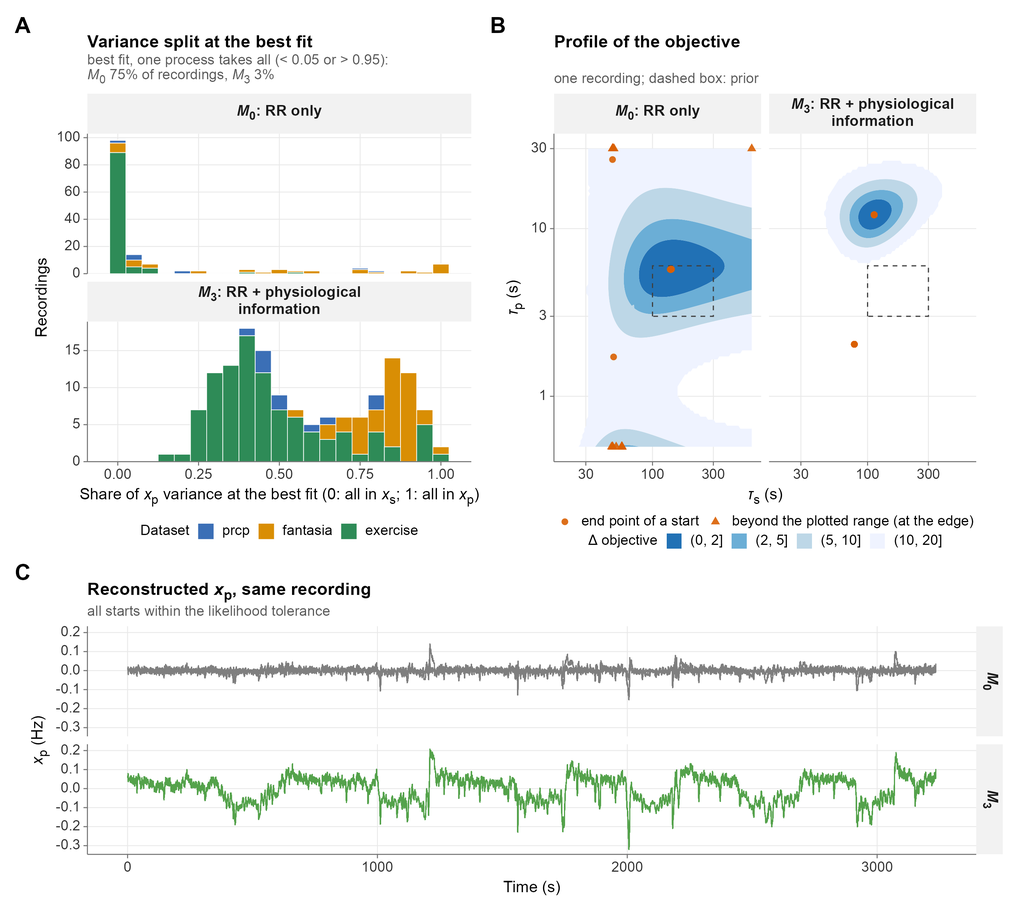

Figure 1: Non-identifiability under RR alone. (A) Share of $x_p$ variance at the best fit of each recording, under $M_0$ (RR only) and $M_3$ (with physiological information); values at 0 or 1 mean that one process absorbs essentially all variability (the share of recordings is for the best fit only; the text reports the share of all fits). The single solution under $M_3$ is conditional on the spectral anchor and the priors. (B) Profile of the objective over $(\tau_s, \tau_p)$ for one recording, with the end points of its starts and the prior interval (dashed box); white areas inside the plotted range are grid points without a finite value. Under $M_3$, 21 of the 100 starts of this recording stopped at a local optimum 191 log-likelihood units below the best fit (outside the contours); the others reached the same optimum. (C) Reconstructed vagal-like state $x_p$ of the near-equivalent starts of the same recording.

## 3.2 Physiological information reduces solution ambiguity

The specifications are compared in Table 3 on the dispersion of solutions, the stability of the trajectories, the location of the parameters and the RR fit. Improved likelihood is not the criterion, since a well-chosen constraint can reduce ambiguity at a cost in fit; this cost is reported.

Table 3: Ambiguity metrics of the multi-start fits by specification (median [2.5th, 97.5th percentile] across recordings; for the two proportions of fits, one-process collapse and fits within the prior intervals, the mean across recordings [2.5th, 97.5th percentile of the per-recording values]). Large upper percentiles of the dispersion of ln $\tau$ come from recordings in which near-equivalent fits end at vanishingly small or very large time constants, a symptom of the likelihood ridge; they indicate that the fits are not pinned down, not their magnitude.

| Metric | $M_0$ | $M_1$ | $M_2$ | $M_3$ |
| --- | --- | --- | --- | --- |
| Distinct solutions | 23.50 [6.72, 56.38] | 2.00 [1.00, 4.00] | 20.50 [6.00, 51.10] | 1.00 [1.00, 2.00] |
| Near-equivalent fits | 60.00 [1.00, 100.00] | 96.00 [15.87, 100.00] | 91.00 [1.00, 100.00] | 100.00 [44.90, 100.00] |
| SD of ln $\tau_p$ (near-equiv.) | 0.00 [0.00, 18.60] | 0.00 [0.00, 0.08] | 0.05 [0.00, 19.63] | 0.00 [0.00, 0.00] |
| SD of ln $\tau_s$ (near-equiv.) | 0.01 [0.00, 3.13] | 0.00 [0.00, 0.03] | 2.83 [0.00, 14.61] | 0.00 [0.00, 0.00] |
| Range of $x_p$ variance share | 0.00 [0.00, 1.00] | 0.00 [0.00, 0.04] | 0.29 [0.00, 0.99] | 0.00 [0.00, 0.00] |
| One-process collapse | 75% [15%, 99%] | 83% [0%, 100%] | 23% [0%, 100%] | 4% [0%, 59%] |
| Within prior intervals | 4% [0%, 50%] | 77% [0%, 100%] | 1% [0%, 1%] | 18% [0%, 100%] |
| Best RMSE (ms) | 1.00 [0.00, 65.56] | 3.10 [0.00, 65.58] | 3.16 [0.00, 66.98] | 3.39 [0.02, 65.75] |

The median SD of $\ln\tau_s$ among near-equivalent fits was 0.01 for $M_0$, 0.00 for $M_1$, 2.83 for $M_2$, 0.00 for $M_3$ (lowest under $M_3$). The best RR error differed by at most 2.40 ms (240%) between specifications, and the share of fits with both time constants inside the 95% prior intervals was 4% for $M_0$, 77% for $M_1$, 1% for $M_2$ and 18% for $M_3$. One process absorbed essentially all variability in 75% under $M_0$, 83% under $M_1$, 23% under $M_2$ and 4% under $M_3$ of the fits. Time-scale priors alone ($M_1$) therefore did not prevent one-process solutions, whereas the specifications that include the spectral anchor ($M_2$, $M_3$) largely did; the lower ambiguity under $M_3$ thus comes largely from fixing the variance ratio of the two drives through the anchor, and it should not be read as evidence that the apportionment between the drives is correct. The $M_3$ estimates lay inside the 95% prior interval in 19% ($\tau_p$) and 99% ($\tau_s$) of recordings, with a median posterior contraction of 0.59 and 0.57 for $\ln\tau_p$ and $\ln\tau_s$, respectively. For the vagal-like drive, most estimates therefore lay outside the 95% prior interval, so the data moved $\tau_p$ away from the central region of its prior; this may reflect slower fluctuations being absorbed by the faster drive, and it limits the reading of $\tau_p$ as a strictly vagal time constant. In simulations with known truth, when the true time constants lay outside the prior intervals, the median absolute log-error of $\tau_s$ was 1.32 for $M_0$ and 0.98 for $M_3$ (the $M_3$ error was lower than the $M_0$ error); when they lay inside, 1.40 and 0.19. These values delimit the claim: constraints that help when the truth is compatible with them can bias the estimates when it is not. The 95% intervals of the filtered $M_3$ states, which are conditional on the MAP parameters, contained the true state at 70% to 100% of the time points across the four scenarios; the lowest coverage was that of $x_s$ in the sympathetic-dominant variance scenario (70%).

Simulations from the model itself locate where the decomposition can be recovered (30 recordings per condition; Supplementary Figure S11): with $M_3$, the correlation between the filtered sympathetic-like state and the truth was 0.38–0.55 when $\tau_s/\tau_p$ was 4 or less, 0.65–0.68 at 10 and 0.54–0.80 at 30–100 with recordings of 10–30 min. Without physiological information ($M_0$), one drive absorbed all the variance in 66% of the fits when the ratio was below 10 and in 17% when it was 10 or more (at least 10 min); with $M_3$, in 0% and 0%, so the priors prevent the collapse but cannot create identifiability where the time scales overlap. The weaker drive is the one that is lost: with $\lambda_P$ = 20 the correlation of the sympathetic-like state was 0.25–0.38, and with $\lambda_P$ = 0.2 that of the vagal-like state was 0.57–0.63.

For $M_3$, optimization converged for 313 of 313 recordings (100.0%; exercise (n = 263), fantasia (n = 40), prcp (n = 10)). The filtered reconstruction of RR had an in-sample MAPE of 0.222% [0.003, 5.544] and an RMSE of 2.611 ms [0.025, 89.252]. The innovation diagnostics indicated residual serial structure or a departure from the assumed innovation distribution in most recordings (the KS distance was below its critical value in 22% of them): the median KS distance was $D$ = 0.056 [0.023, 0.177] against a mean critical value of 0.0376, compared with 0% of well-specified simulations exceeding it, and 13.0 PACF lags lay outside the approximate bounds on average (Supplementary Figure S10). This residual structure plausibly reflects respiratory and baroreflex oscillations that the model does not represent, and the states are conditional on it. The e-folding times were 15.05 s [2.61, 44.17] (vagal drive) and 150.0 s [112.6, 220.9] (sympathetic drive), MAP estimates under informative priors and the enforced ordering (supplementary section “Fit and innovation diagnostics”).

## 3.3 Latent states during orthostatic perturbation

In the PRCP recordings, the tilts were taken from the tilt-angle signal where available (10 of 10 recordings) and from the protocol annotations otherwise; 40 tilts and 20 stand-ups were analyzed. The states of one recording and the average response to a tilt are shown in Figure 2.

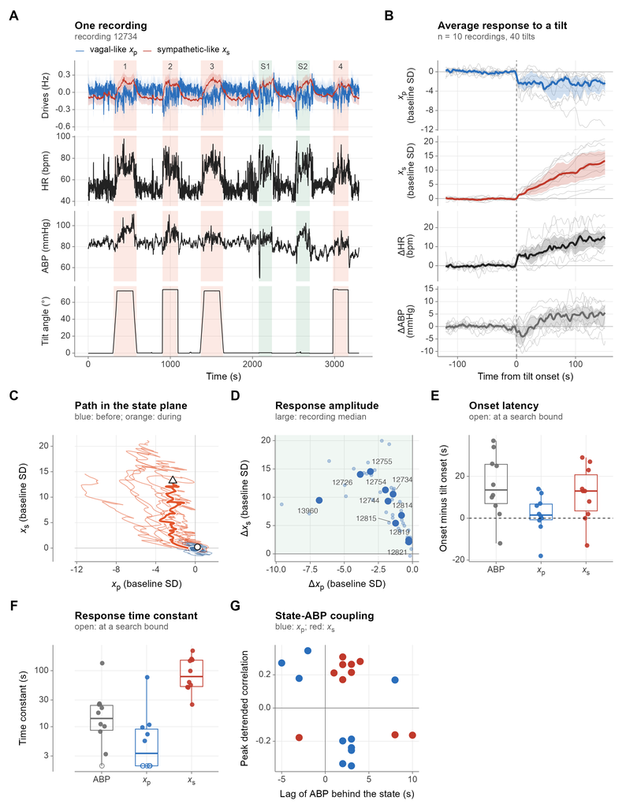

Figure 2: Latent states during repeated orthostatic perturbation. (A) One recording (recording 12734, median standardized response): filtered drives (blue, vagal-like $x_p$; red, sympathetic-like $x_s$) with 95% intervals conditional on the MAP parameters, heart rate, mean arterial pressure (ABP) and tilt angle; each tilt is shaded and numbered, and each stand-up (green) is labeled S. (B) All tilts aligned on their onset, each relative to its own baseline (states in baseline SDs; heart rate and ABP as changes); the line is the median over recordings, the band the quartiles and the grey lines the individual recordings. (C) Median path of the two states in the $(x_p, x_s)$ plane in baseline SDs. (D) Standardized change of the two states between baseline and tilt (large points: recordings; small points: individual tilts); changes of $x_s$ reach tens of baseline SDs because the baseline SD of $x_s$ is small. (E) Onset of the response of each state, and of ABP when available, relative to the tilt onset (open symbols: at a search bound). (F) Step-response time constants. (G) Peak lagged correlation between each state and ABP after detrending, with its lag (the sign differs between recordings, so it is not a consistent coupling). When recordings with several tilt-angle levels are available, a further panel shows the mean states, heart rate and ABP by angle. The accuracy of the heart-rate-based events is shown in Supplementary Figure S5.

Responses by kind of maneuver, the arterial-pressure response and its lagged correlation with the states, the dose–response over tilt angle and the comparison with a CWT moving spectrum are reported in the supplementary material (sections “Secondary analyses of the perturbation” and “Responses by type of maneuver”).

## 3.4 The latent representation across healthy aging

Among 20 young and 20 older adults, 8 of 11 latent variables reached $|\delta| \geq 0.33$: $\tau_p$ (higher in older adults, $\delta$ = 0.72; adjusted $p < 0.05$), $\lambda_P$ (lower in older adults, $\delta$ = -0.53; adjusted $p < 0.05$), $\hat\sigma^2_{sys}$ (lower in older adults, $\delta$ = -0.71; adjusted $p < 0.05$), the SD of $x_p$ (lower in older adults, $\delta$ = -0.81; adjusted $p < 0.05$), the SD of $x_s$ (lower in older adults, $\delta$ = -0.61; adjusted $p < 0.05$), the SD ratio $x_p/x_s$ (lower in older adults, $\delta$ = -0.54; adjusted $p < 0.05$), $\ln(\kappa_p/\kappa_s)$ (lower in older adults, $\delta$ = -0.69; adjusted $p < 0.05$) and the share of $x_p$ variance (lower in older adults, $\delta$ = -0.54; adjusted $p < 0.05$); 2 of 4 HRV variables reached $|\delta| \geq 0.33$: SDNN (lower in older adults, $\delta$ = -0.71; adjusted $p < 0.05$) and RMSSD (lower in older adults, $\delta$ = -0.81; adjusted $p < 0.05$). These latent summaries are not independent: the share of $x_p$ variance is a monotone function of the SD ratio of the two states, both depend strongly on the spectral anchor $\lambda_P$, $\ln(\kappa_p/\kappa_s)$ combines the two time constants, and $\sigma^2_{sys}$ and the SDs of the states scale with the overall amplitude of variability, so that the count above overstates the number of distinct dimensions in which the groups differ. Agreement between two non-overlapping windows of the same recording (ICC of the log values) had a median of 0.88 for the latent summaries and 0.93 for the conventional HRV metrics; the lowest agreement was that of $\tau_s$ (0.31). With these group sizes, all comparisons are exploratory, and no continuous age, sex or other covariates were available. When the priors of the time constants were replaced by weak ones or by empirical-Bayes priors estimated on the other half of the subjects, the test-retest ICC of the amplitudes stayed at 0.88–0.95, that of $\tau_p$ was 0.88, 0.54 and 0.70 and that of $\tau_s$ 0.31, 0.48 and 0.54 (production, weak, empirical Bayes; supplementary material), so the slow time constant carries recording-specific information that the fixed prior suppresses but remains the least reliable summary. Group contrasts are shown in Figure 3 and listed, with the respiration measures, in the supplementary section “Additional analyses of the Fantasia recordings”.

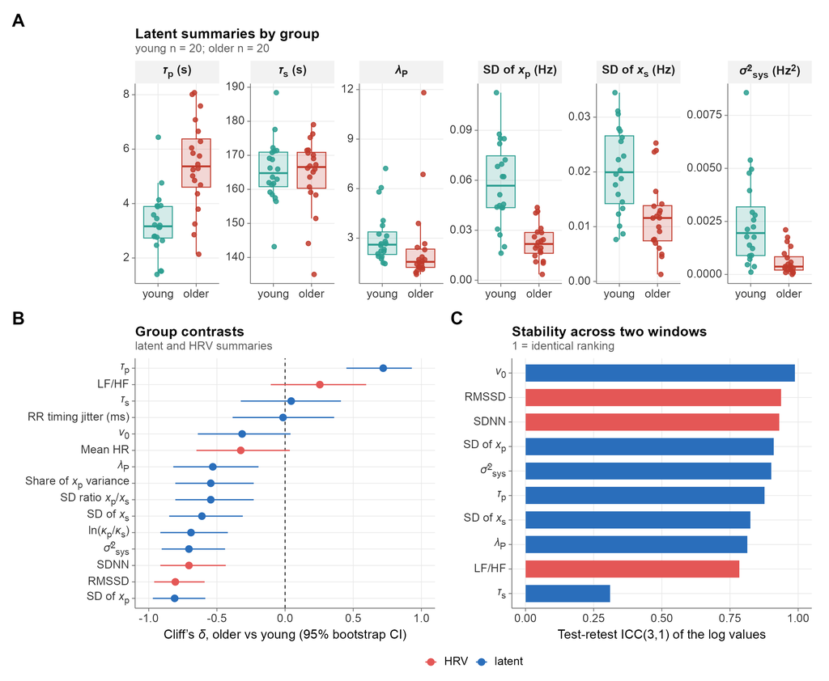

Figure 3: Latent representation in young and older adults. (A) Distributions of latent summaries by group. (B) Effect sizes (Cliff’s $\delta$, older versus young) for latent and conventional HRV variables. (C) Test-retest agreement (ICC(3,1) of log values) between two non-overlapping windows.

## 3.5 Latent dynamics during exercise and recovery

In the two-minute step-test recordings, the reconstruction tracked the changes in RR across rest, exercise and recovery (Figure 4, panel A). The recovery definition (90% recovery of the excursion) and the end-of-exercise rule (offset time of the fitted exercise profile) were those selected by the simulation benchmark (Supplementary Figure S3).

In 263 of 263 exercise recordings the rest, exercise and recovery phases could be defined from heart rate. From rest to the end of exercise, the vagal-like state changed by -7.9 [-26.9, -1.4] and the sympathetic-like state by 24.9 [5.5, 59.5] rest SDs, with a heart-rate increase of 40 [19, 117] bpm (median [2.5th, 97.5th percentile] across recordings). Recovery times (90% recovery of the excursion; Kaplan-Meier medians) were 42 s for the vagal-like state (1% of recordings censored) and 341 s for the sympathetic-like state (37% of recordings censored). For a first-order relaxation, recovery to 90% of the excursion takes about $2.3\,\tau$, so these times are of the order implied by the estimated time constants, which are themselves shaped by their priors; they describe the fitted kinetics and are not independent measurements of recovery. The path in the state plane had a median length of 214 [95, 590], an enclosed area of 215 [38, 1051] and a maximum energy $E$ of 253 [36, 1525] in rest-SD units. In the state plane, the strongest basin of the occupied region (the mode of the density of the filtered states) was displaced from its position in the rest phase by 9.3 rest-SD units to the exercise phase and 2.3 rest-SD units to the recovery phase (Supplementary Figure S6); the number of basins detected was 1 in the rest phase, 3 in the exercise phase, 1 in the recovery phase. The landscape is a descriptive map of where the states lie and is not a fitted potential of the model. Conventional HRV metrics predicted the latent summaries of this cohort with a median leave-one-out $R^2$ of 0.39. The strongest rank correlation between a latent response and an HRV change was -0.65 (standardized change of the vagal-like state with the change in SDNN, n = 263). No subject characteristics or clinical and functional outcomes were available for this cohort, so the analysis is descriptive and no association with such variables is reported.

Descriptors of the perturbation response computed from the states with their uncertainty, as proposed for latent autonomic trajectories [37], gave a median time to a sustained return to the resting region of 173 s (10th–90th percentile 80–311) after exercise, which correlated with the recovery times above at Spearman 0.72 ($x_p$) and 0.63 ($x_s$); the probability of return depended mainly on the horizon (0.27, 0.75 and 0.97 at 120, 300 and 600 s), and in simulations the recovery time was recovered in rank but not exactly (Supplementary Figure S12).

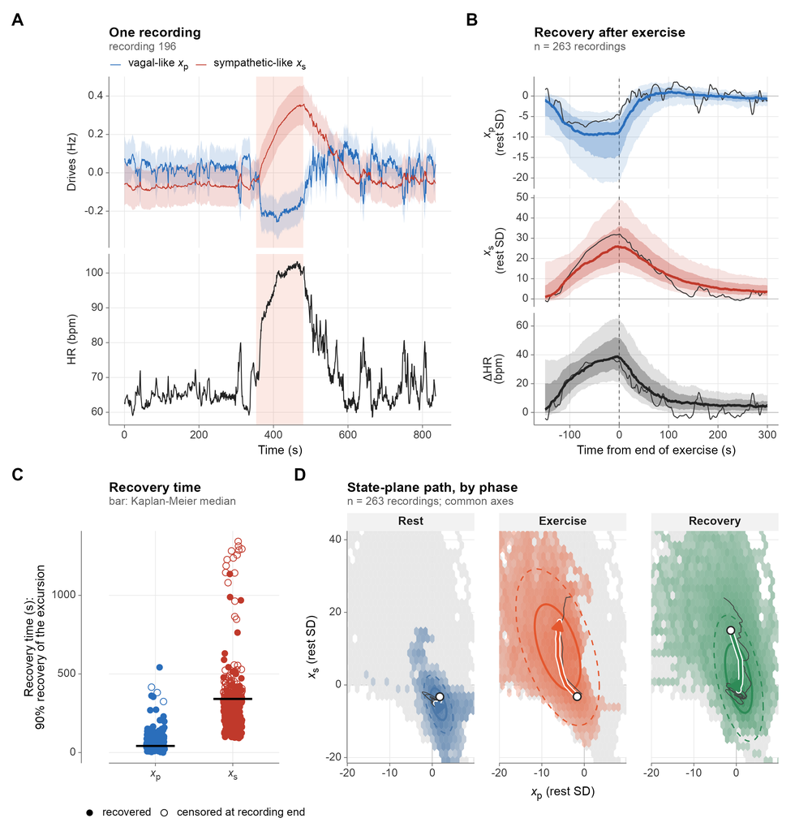

Figure 4: Adaptation and recovery in older adults. (A) One recording (recording 196, median standardized response): filtered states and heart rate, with the detected exercise shaded. (B) All recordings aligned on the end of exercise, each relative to its rest level (median, bands of 25–75% and 10–90% of recordings, and the recording of A). (C) Recovery times of each state (open symbols: right-censored at the end of the recording; bars: Kaplan–Meier medians). (D) Filtered states in the $(x_p, x_s)$ plane in rest-SD units, one panel per phase on common axes (central 99% of the pooled points): density of the points of the phase (colored hexagons) over that of all phases (grey), ellipses holding 50% (solid) and 90% (dashed) of them, and the median path through the phase (arrow; open circle: start).

## 3.6 Response to pharmacological blockade

We fitted $M_3$, unchanged, to 81 five-minute segments of 7 volunteers who received saline, atropine (0.04 mg/kg) and propranolol (0.2 mg/kg). Relative to saline of the same session (geometric mean over volunteers), atropine reduced the standard deviation (SD) of the vagal-like drive to 0.16 (95% CI 0.11–0.21) during spontaneous breathing (below 0.3 in 6 of 6 volunteers) and to 0.18 (95% CI 0.13–0.22) with paced breathing, while heart rate rose by a median of 47 bpm; with propranolol added it fell to 0.10 (95% CI 0.07–0.16). Propranolol alone did not reduce it (ratio 1.42, 95% CI 0.96–2.06; at least 0.8 of saline in 6 of 7 volunteers). The SD of the sympathetic-like drive, however, also fell under atropine, to 0.26 (95% CI 0.16–0.40; by more than a factor of three in 3 of 6 volunteers), and to 0.13 (95% CI 0.08–0.23) under the double blockade: once the vagal part of the spectrum is removed, the spectral anchor re-assigns the variance, so the slow drive is not independent of the fast one in this reconstruction. In the same volunteers the integrated muscle sympathetic nerve signal (MSNA) was higher in the second half of a breath-hold than at baseline in 11 of 14 sessions, but the sympathetic-like state rose in only 3 of 14 (median change -1.3 baseline SDs), and across sessions the change of MSNA correlated with that of $x_s$ at Spearman -0.17 ($x_p$ -0.13, heart rate 0.01); during hyperventilation $x_s$ rose in 14 of 14 sessions, $x_p$ fell in 13 of 14 and heart rate rose in 14 of 14, and the median lag-0 correlation of $x_s$ with MSNA over the whole saline period was 0.05. The blockade therefore supports the identity of the fast drive, and the maneuvers show that the slow drive behaves as an acceleratory component of the heart rate, as it is defined, and not as a measure of sympathetic outflow (Figure 5).

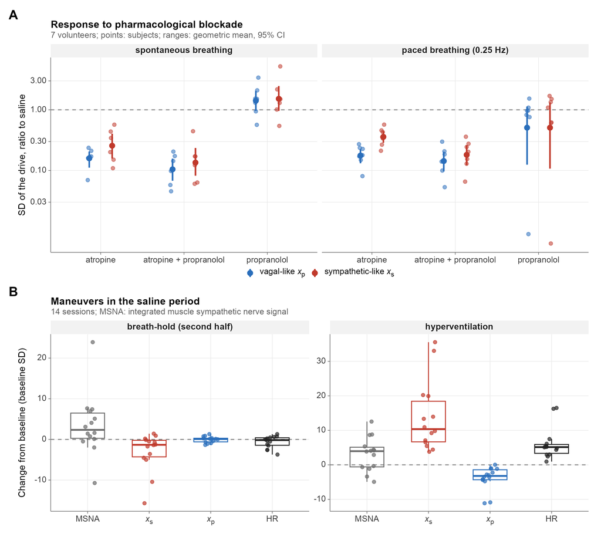

Figure 5: Pharmacological blockade and autonomic maneuvers (public dataset of seven healthy volunteers). (A) SD of the vagal-like and sympathetic-like drives under each drug as a ratio to saline of the same day, by breathing mode (points: volunteers; ranges: geometric mean and bootstrap 95% interval; dashed line: no change; logarithmic axis). (B) Change from the resting baseline, in baseline SDs, of the integrated muscle sympathetic nerve signal (MSNA), the two states and heart rate in the second half of a breath-hold and during hyperventilation, in the saline period of each session (points: sessions).

# 4 Discussion

## 4.1 Principal observations

We examined whether a physiology-informed state-space model can reconstruct model-conditional autonomic dynamics from RR intervals when the latent decomposition is not identified by RR alone. In the recordings analyzed, adding the physiological information reduced the number of distinct latent solutions and the occurrence of one-process solutions relative to RR alone at a cost in RR error. In the datasets analyzed, the innovation diagnostics indicated residual serial structure or a departure from the assumed innovation distribution in most recordings, so the reconstructions are conditional on a noise model that holds only approximately; with this caveat, in the tilt-table, aging and exercise analyses, the vagal-like state decreased and the sympathetic-like state increased in most tilt-table recordings; most of the partly redundant latent summaries differed between young and older adults; and the exercise recordings showed a rest-exercise-recovery trajectory whose recovery times are closely tied to the fitted time constants. Beyond these checks of internal consistency, one external test was possible: in a public blockade dataset, the vagal-like drive behaved as a vagal component, whereas the sympathetic-like drive was not independent of it and did not follow sympathetic nerve activity. The representation is therefore best read as a fast drive with pharmacological support and a slow drive defined by its time scale.

## 4.2 Physiological meaning and relation to conventional HRV

The latent trajectories are physiologically constrained reconstructions: they describe the drives that the model needs, given its kinetic and spectral assumptions, to account for the observed interval timing, and this is the sense in which the components are called vagal-like and sympathetic-like. During orthostatic tilt, the reconstructed vagal-like state decreased and the sympathetic-like state increased in 10 of 10 recordings (100%), a pattern consistent with the expected autonomic adaptation to orthostatic stress. The same contrast was clearly less frequent in the resting baselines (negative control), where it reflects drift and not a perturbation. The pharmacological data add an external test that the main datasets lack: the vagal-like drive lost most of its variability under atropine (0.16 of saline) and not under propranolol alone (1.42), as a vagal component should, whereas the sympathetic-like drive lost variability under atropine too and did not follow muscle sympathetic nerve activity during breath-holds; the label of the fast drive is therefore supported by blockade, and that of the slow drive remains a statement about its time scale. The path geometry in the $(x_p, x_s)$ plane and the quadratic energy $E$ are descriptive devices, not an energy or a dissipation of the physiological system.

Conventional HRV summarizes how variable RR is; SPARK asks what latent state could account for how RR changes and how that state responds and recovers, so the two are complementary. For signal processing, the representation offers what window-based estimates do not: once the recording-level parameters are fitted, the states are updated at every beat without a stationarity window, irregular sampling is handled exactly, and each state carries an uncertainty interval. Window-based spectral estimates trade temporal against frequency resolution under non-stationarity [5,11]; the comparison with a CWT moving spectrum (supplementary material) depends on the assumptions of the filter and does not establish general superiority. In the Fantasia recordings, HRV metrics predicted the latent summaries with a median leave-one-out $R^2$ of 0.42, so that a substantial part of their variation was not linearly recoverable from SDNN, RMSSD and mean heart rate. Incomplete prediction from a limited set of HRV metrics does not establish incremental clinical value, which requires independent outcomes.

## 4.3 Identification and physiological priors

In an underdetermined inverse problem, physiological knowledge is part of the identification structure (Table 1), and two consequences follow. First, the kinetic estimates are posterior modes under informative priors that are fixed across recordings: they are regularized toward the priors but not bounded by them, differences in $\kappa$ between groups should be read together with the prior–posterior contrast, and the separation of fast and slow time scales is built into the structure, not an empirical finding. The boundary simulations show that the priors prevent one-process collapse but cannot create identifiability where the time scales overlap. Second, the spectral anchor assigns branch energy by frequency and is computed from the same recording; conditions in which the two branches overlap in frequency, such as strong orthostatic stress or exercise, may lead to misattribution between the drives [8,39]. The pharmacological evidence on which the spectral weights are based was drawn from the literature. In the one blockade dataset analyzed here, atropine left 0.8% of the RR variance of saline (geometric mean), consistent with reports that at rest vagal blockade removes most of the power at low as well as high frequencies [34]; the weights instead assign most low-frequency variance to the sympathetic branch, which helps explain why the sympathetic-like amplitude fell under vagal blockade and makes the allocation of low-frequency variance the weakest part of the anchor. Varying the physiological hyperparameters one at a time changed the time constants by a median absolute log-ratio of at most 0.64 and left the reconstructed trajectories correlated at least 0.99 with the reference. The direction and time course of the reconstructed states were therefore robust to these settings. Correlations are insensitive to a change of scale, however, and do not address how variance is apportioned between the two drives: the share of latent variance attributed to the vagal-like process changed by a median absolute 0.23 at most, for the vagal floor (0.5), and by 0.37 when the spectral anchor was removed, so statements about the split between the two drives are conditional on the anchor settings (see the limitations).

## 4.4 Phase-domain formulation and relation to existing approaches

Point-process models of heartbeat intervals based on generalized linear structures are largely phenomenological with respect to the sinoatrial node [15,40], and state-space formulations of integral pulse frequency modulation generally solve the nonlinear first-passage observation in the time domain with extended or unscented filtering [14,17,18]. By conditioning on the observed interval, SPARK obtains a measurement equation that is linear in the integrated drives, together with exact Ornstein–Uhlenbeck transitions across irregular intervals, so the filter is exact and needs no time-stepping approximation; the same structure makes it inexpensive enough to run in a web browser. The price is the terminal-threshold approximation, whose neglected boundary term is bounded in proportion to the ratio of diffusion to the square root of the drift (supplementary material); in the fitted recordings, $\varepsilon = s_{RR}/\Delta t$ had a median of 0.0063 (maximum 0.0579), corresponding to a bound of at most 0.0116 on the CDF discrepancy. Under strict first passage the interval variance also scales with the inverse cube of the drift, a dependence that SPARK does not represent (supplementary sections “Interval-variance scaling” and “Extended methods and discussion”).

## 4.5 Limitations

The latent states are model-based reconstructions and not measurements of autonomic neural activity; The comparison with pharmacological blockade and with muscle sympathetic nerve activity rests on 7 young volunteers studied supine and at rest in a single public dataset; blockade is not additive and may be incomplete, and it supported only the fast drive: the slow drive lost variability under vagal blockade and did not follow the nerve signal, so it is a slow component of the heart rate and not a measurement of sympathetic outflow. The innovation diagnostics indicated residual serial structure or a departure from the assumed innovation distribution in most recordings (the KS distance was below its critical value in 22% of them), so the reported intervals are conditional on a noise model that holds only approximately. The vagal-like time constant lay inside its 95% prior interval in 19% of recordings, so it should not be read as a strictly vagal time constant: the faster drive may absorb slower fluctuations, such as baroreflex-related oscillations. Recovery times and time constants are shaped by their priors, and in recordings whose duration is comparable to or shorter than the sympathetic time scale, $\tau_s$ is informed mainly by its prior. The hyperparameters are fixed across recordings, kinetics and variances are constant within a recording, the states are filtered and not smoothed, a better local optimum cannot be excluded for an individual recording, and the simulations use data generated by the model itself. The apportioning of a perturbation-induced change between the two drives depends on the spectral anchor: in the sensitivity analyses the share of latent variance attributed to the vagal-like process changed by a median absolute 0.10 or more with the vagal floor, the spectral crossover and the $\tau_p$ prior interval. For the same reason the tonic level of each drive is not identified, because $\nu_0$ and constant offsets of $x_p$ and $x_s$ enter the likelihood only through their combination with the mean rate; comparisons of variability, kinetics and mean rate are supported, but not of absolute vagal or sympathetic tone.

The responses by type of maneuver rest on 20 slow tilts, 20 rapid tilts, 20 stand-ups (at most 2 events of a kind per recording) and are descriptive. The tilt-table dataset is small (10 recordings), its tilts are not independent within a recording, and events detected from RR are not independent evidence about the states. Sex and gender were not analyzed: sex is not reported for the PRCP participants or attached to the exercise recordings, six of the seven blockade volunteers were men, and the Fantasia groups are balanced by sex but too small for sex-stratified analyses, so sex differences in the latent dynamics remain untested. The exercise cohort has a single protocol and no clinical outcomes, so the clinical relevance of the trajectories and their behavior in overt autonomic pathology were not evaluated [41,42]. Finally, the single-stream formulation has no respiratory or blood-pressure inputs: respiratory sinus arrhythmia is captured only within the vagal state and baroreflex feedback is implicit [8,43,44], so central autonomic commands cannot be distinguished from peripheral mechanical modulation.

## 4.6 Future directions

Concurrent respiratory and arterial-pressure signals could enter through explicit coupling terms [45–47], reducing reliance on the spectral anchor; larger blockade studies with graded doses and microneurography [48,49] could calibrate the allocation of low-frequency variance; and hierarchical formulations could learn the hyperparameters across recordings. Datasets with clinical outcomes would show whether the trajectories and their perturbation-response descriptors carry prognostic information, and quantities such as the phase-plane geometry or critical slowing down of the kinetics [50,51] could be explored, each requiring dedicated validation.

# 5 Conclusion

SPARK reconstructs latent cardiac autonomic dynamics from RR intervals with an exact continuous-time filter and an explicit physiological identification structure. In the datasets analyzed, this structure reduced solution ambiguity and one-process collapse at a cost in RR error, and the reconstructed states responded coherently to orthostatic and exercise-related challenges. Under pharmacological blockade the fast drive behaved as a vagal component, whereas the slow drive was not independent of it and did not follow sympathetic nerve activity. SPARK is therefore suited as an interpretable, uncertainty-aware dynamical representation of RR for exploratory and methodological research, in which the fast drive has external support and the slow drive is defined by its time scale. Residual structure, conditional intervals and the dependence of variance allocation on the spectral anchor remain limitations, and interpretation of the components as quantitative measures of parasympathetic and sympathetic activity requires further independent validation.

# CRediT authorship contribution statement

**Matías Castillo-Aguilar:** Conceptualization; Methodology; Software; Validation; Formal analysis; Investigation; Resources; Data curation; Writing – original draft; Writing – review & editing; Visualization. **Noah Beelders:** Conceptualization; Validation; Writing – review & editing. **Cristian Núñez-Espinosa:** Writing – review & editing; Supervision; Project administration; Funding acquisition.

# Declaration of competing interest

The authors declare that they have no known competing financial interests or personal relationships that could have appeared to influence the work reported in this paper.

# Funding

This work was supported by the Agencia Nacional de Investigación y Desarrollo (ANID), Proyecto FONDECYT Regular [grant number 1250474], awarded to C.N.-E. The funder had no role in the study design, analysis, interpretation of results, writing of the report, or the decision to submit the article for publication.

# Ethics statement

The exercise cohort is a secondary analysis of recordings from a previously published study [33], which was approved by the Ethics Committee of the University of Chile (ACTA No. 029 − 18/05/2022) and the Ethics Committee of the University of Magallanes (No. 008/SH/2022). No new data were collected for the present work, and only the RR-interval series, identified by a recording number, were used, so no additional ethical approval was required. The PRCP and Fantasia recordings are publicly available, de-identified datasets from PhysioNet, analyzed secondarily under their open license (Open Data Commons Attribution 1.0). The blockade recordings are a public, de-identified dataset of Lancaster University, analyzed secondarily under its license (Creative Commons Attribution-NonCommercial); the original study had its own ethical approval [34].

# Code availability

The model is implemented in R (engine deposited with this article as model_code.R). An equivalent implementation runs entirely in the browser, without uploading data, at https://matcasti.github.io/SPARK-app/. In the five reference series tested, its likelihood, states and parameter estimates agree with those of the R engine (fitted parameters to within 10<sup>-5</sup>, relative; states, in Hz, to within 10<sup>-6</sup>). The application is intended for research use and exploration, not for clinical decisions.

# Data availability

The PRCP recordings (Physiologic Response to Changes in Posture; https://doi.org/10.13026/C2PC7R) and the Fantasia database (https://doi.org/10.13026/C2RG61) are publicly available from PhysioNet [52] under the Open Data Commons Attribution license; the repository downloads them with checksum verification (`make download`). The blockade recordings are available from Lancaster University (https://doi.org/10.17635/lancaster/researchdata/280, Creative Commons Attribution-NonCommercial); the repository prepares them from the downloaded file (`make prep`). The RR-interval series of the exercise cohort (263 recordings, without personal identifiers) are in the repository’s `data-raw/tmst` folder. The analysis code and its configuration are at https://github.com/matcasti/SPARK-model/, and the figures, tables and numbers of this article are regenerated from them (`make data`, `make run`, `make render`). The repository is public and under version control; the version used for this article is the release v1.1.0 (https://github.com/matcasti/SPARK-model/releases/tag/v1.1.0), which fixes the code and configuration at a dated commit and carries the result files of the article, whose checksums are listed in the repository (`results/MANIFEST.csv`). The release is not deposited in a repository that issues a DOI.

# Declaration of generative AI and AI-assisted technologies in the writing process

During the preparation of this work the authors used Claude (Anthropic) to assist with drafting and language editing of the text. After using this tool, the authors reviewed and edited the content as needed and take full responsibility for the content of the publication.

# References

[1]

Kashou AH, Basit H, Chhabra L. [Physiology, sinoatrial node](https://www.ncbi.nlm.nih.gov/books/NBK459238/). StatPearls, Treasure Island (FL): StatPearls Publishing; 2022.

[2]

Hennis K, Piantoni C, Biel M, Fenske S, Wahl-Schott C. Pacemaker channels and the chronotropic response in health and disease. Circulation Research 2024;134:1348–78. https://doi.org/10.1161/circresaha.123.323250.

[3]

Maltsev AV, Stern MD, Lakatta EG, Maltsev VA. A novel conceptual model of heart rate autonomic modulation based on a small-world modular structure of the sinoatrial node. Frontiers in Physiology 2023;14:1276023. https://doi.org/10.3389/fphys.2023.1276023.

[4]

Varzideh F, Jankauskas SS, Mone P, Kansakar U, Santulli G. Autonomic neurotransmission in cardiovascular regulation and pathophysiology. Frontiers in Neuroscience 2026;19:1739330. https://doi.org/10.3389/fnins.2025.1739330.

[5]

Saul JP, Valenza G. Heart rate variability and the dawn of complex physiological signal analysis: Methodological and clinical perspectives. Philosophical Transactions of the Royal Society A: Mathematical, Physical and Engineering Sciences 2021;379:20200255. https://doi.org/10.1098/rsta.2020.0255.

[6]

Rahman S, Udhayakumar R, Kaplan D, McCarthy B, Dawood T, Mellor N, et al. Photoplethysmography as a noninvasive surrogate for microneurography in measuring stress-induced sympathetic nervous activation—a machine learning approach. Computers in Biology and Medicine 2025;185:109522. https://doi.org/10.1016/j.compbiomed.2024.109522.

[7]

Rosas FE, Candia-Rivera D, Luppi AI, Guo Y, Mediano PA. Bayesian at heart: Towards autonomic outflow estimation via generative state-space modelling of heart rate dynamics. Computers in Biology and Medicine 2024;170:107857. https://doi.org/10.1016/j.compbiomed.2023.107857.

[8]

Liu S, Cui Y, Chen M. Heart rate variability: A multidimensional perspective from physiological marker to brain-heart axis disorders prediction. Frontiers in Cardiovascular Medicine 2025;12:1630668. https://doi.org/10.3389/fcvm.2025.1630668.

[9]

Arya P, Singh M, Singh M. Multi-domain analysis of ultra-short-term HRV for breathing pattern classification in wearable health devices. EURASIP Journal on Advances in Signal Processing 2024;2024:99. https://doi.org/10.1186/s13634-024-01194-4.

[10]

Adamczyk K, Polak AG. Online algorithm for deriving heart rate variability components and their time–frequency analysis. Applied Sciences 2025;15:1210. https://doi.org/10.3390/app15031210.

[11]

Kim JW, Seok HS, Shin H. Is ultra-short-term heart rate variability valid in non-static conditions? Frontiers in Physiology 2021;12:596060. https://doi.org/10.3389/fphys.2021.596060.

[12]

Moak JP, Goldstein DS, Eldadah BA, Saleem A, Holmes C, Pechnik S, et al. Supine low-frequency power of heart rate variability reflects baroreflex function, not cardiac sympathetic innervation. Heart Rhythm 2007;4:1523–9. https://doi.org/10.1016/j.hrthm.2007.07.019.

[13]

Yang P-C, Rose A, DeMarco KR, Dawson JR, Han Y, Jeng M-T, et al. A multiscale predictive digital twin for neurocardiac modulation. The Journal of Physiology 2023;601:3789–812. https://doi.org/10.1113/jp284391.

[14]

Candia-Rivera D, Catrambone V, Barbieri R, Valenza G. Integral pulse frequency modulation model driven by sympathovagal dynamics: Synthetic vs. Real heart rate variability. Biomedical Signal Processing and Control 2021;68:102736. https://doi.org/10.1016/j.bspc.2021.102736.

[15]

Barbieri R, Matten EC, Alabi AA, Brown EN. A point-process model of human heartbeat intervals: New definitions of heart rate and heart rate variability. American Journal of Physiology-Heart and Circulatory Physiology 2005;288:H424–35. https://doi.org/10.1152/ajpheart.00482.2003.

[16]

Lin R, Wang Y. Dynamic heartbeat modeling with recurrent neural networks and inverse gaussian point process. arXiv 2026. https://doi.org/10.48550/arXiv.2604.13815.

[17]

Ding L, Wen C. High-order extended kalman filter for state estimation of nonlinear systems. Symmetry 2024;16:617. https://doi.org/10.3390/sym16050617.

[18]

Amor N, Rasool G, Bouaynaya NC. Constrained state estimation–a review. arXiv 2018. https://doi.org/10.48550/arXiv.1807.03463.

[19]

Candia-Rivera D, Vico Fallani F de, Chavez M. Robust and time-resolved estimation of cardiac sympathetic and parasympathetic indices. Royal Society Open Science 2025;12:240750. https://doi.org/10.1098/rsos.240750.

[20]

Warner HR, Cox A. A mathematical model of heart rate control by sympathetic and vagus efferent information. Journal of Applied Physiology 1962;17:349–55. https://doi.org/10.1152/jappl.1962.17.2.349.

[21]

Akselrod S, Gordon D, Ubel FA, Shannon DC, Berger RD, Cohen RJ. Power spectrum analysis of heart rate fluctuation: A quantitative probe of beat-to-beat cardiovascular control. Science 1981;213:220–2. https://doi.org/10.1126/science.6166045.

[22]

Pomeranz B, Macaulay RJB, Caudill MA, Kutz I, Adam D, Gordon D, et al. Assessment of autonomic function in humans by heart rate spectral analysis. American Journal of Physiology-Heart and Circulatory Physiology 1985;248:H151–3. https://doi.org/10.1152/ajpheart.1985.248.1.H151.

[23]

Taylor JA, Carr DL, Myers CW, Eckberg DL. Mechanisms underlying very-low-frequency RR-interval oscillations in humans. Circulation 1998;98:547–55. https://doi.org/10.1161/01.cir.98.6.547.

[24]

Uhlenbeck GE, Ornstein LS. On the theory of the brownian motion. Physical Review 1930;36:823–41. https://doi.org/10.1103/PhysRev.36.823.

[25]

Särkkä S, García-Fernández ÁF. Temporal parallelization of bayesian smoothers. IEEE Transactions on Automatic Control 2021;66:299–306. https://doi.org/10.1109/tac.2020.2976316.

[26]

Reith-Braun M, Pfaff F, Thummy J, Hanebeck UD. Approximate first-passage time distributions for gaussian motion and transportation models. 2023 26th international conference on information fusion (FUSION), IEEE; 2023, p. 1–8. https://doi.org/10.23919/fusion52260.2023.10224164.

[27]

Hughes RA, Kenward MG, Sterne JA, Tilling K. Estimation of the linear mixed integrated ornstein–uhlenbeck model. Journal of Statistical Computation and Simulation 2017;87:1541–58. https://doi.org/10.1080/00949655.2016.1277425.

[28]

Saul JP, Berger R, Albrecht P, Stein S, Chen MH, Cohen Rj. Transfer function analysis of the circulation: Unique insights into cardiovascular regulation. American Journal of Physiology-Heart and Circulatory Physiology 1991;261:H1231–45. https://doi.org/10.1152/ajpheart.1991.261.4.h1231.

[29]

Gruszecki M, Kaufmann D, Świątczak M, Młodziński K, Neary JP, Singh J, et al. Wavelet transform analysis reveals differences between patients with impaired LVEF and healthy individuals. Polish Heart Journal 2024;82:882–5. https://doi.org/10.33963/v.phj.101280.

[30]

Zhuravlev MO, Runnova AE, Mironov SA, Zhuravleva JA, Kiselev AR. Continuous estimation of heart rate variability from electrocardiogram and photoplethysmogram signals with oscillatory wavelet pattern method. Sensors 2025;25:5455. https://doi.org/10.3390/s25175455.

[31]

Hayano J, Sakakibara Y, Yamada MY, Yamada N, Mukai S, Fujinami T, et al. Accuracy of assessment of cardiac vagal tone by heart rate variability in normal subjects. The American Journal of Cardiology 1991;67:199–204. https://doi.org/10.1016/0002-9149(91)90445-Q.

[32]

Hopf H-B, Skyschally A, Heusch G, Peters J. Low-frequency spectral power of heart rate variability is not a specific marker of cardiac sympathetic modulation. Anesthesiology 1995;82:609–19. https://doi.org/10.1097/00000542-199503000-00002.

[33]

Castillo-Aguilar M, Mabe-Castro D, Medina D, Núñez-Espinosa C. Enhancing cardiovascular monitoring: A non-linear model for characterizing RR interval fluctuations in exercise and recovery. Scientific Reports 2025;15:8628. https://doi.org/10.1038/s41598-025-93654-6.

[34]

Clemson PT, Hoag JB, Cooke WH, Eckberg DL, Stefanovska A. Beyond the baroreflex: A new measure of autonomic regulation based on the time-frequency assessment of variability, phase coherence and couplings. Frontiers in Network Physiology 2022;2:891604. https://doi.org/10.3389/fnetp.2022.891604.

[35]

Heldt T, Oefinger M, Hoshiyama M, Mark R. Circulatory response to passive and active changes in posture. Computers in cardiology, IEEE; 2003, p. 263–6. https://doi.org/10.1109/cic.2003.1291141.

[36]

Iyengar N, Peng C, Morin R, Goldberger AL, Lipsitz LA. Age-related alterations in the fractal scaling of cardiac interbeat interval dynamics. American Journal of Physiology-Regulatory, Integrative and Comparative Physiology 1996;271:R1078–84. https://doi.org/10.1152/ajpregu.1996.271.4.r1078.

[37]

Castillo-Aguilar M, Mabe-Castro D, Núñez-Espinosa C. A systems theory of cardiac-autonomic trajectories and equilibria (STATE) 2026. https://doi.org/10.64898/2026.11.02.763675.

[38]

Lancaster University. Blocker data 2019. https://doi.org/10.17635/lancaster/researchdata/280.

[39]

Menuet C, Ben-Tal A, Linossier A, Allen AM, Machado BH, Moraes DJ, et al. Redefining respiratory sinus arrhythmia as respiratory heart rate variability: An international expert recommendation for terminological clarity. Nature Reviews Cardiology 2025;22:978–84. https://doi.org/10.1038/s41569-025-01160-z.

[40]

Chen Z, Purdon PL, Brown EN, Barbieri R. A unified point process probabilistic framework to assess heartbeat dynamics and autonomic cardiovascular control. Frontiers in Physiology 2012;3:4. https://doi.org/10.3389/fphys.2012.00004.

[41]

Braffett BH, El Ghormli L, Martin C, White NH, Hirsch IB, Bantle A, et al. Cardiovascular autonomic neuropathy defined by indices of heart rate variability is associated with cardiovascular disease: A longitudinal cohort study of participants with type 1 diabetes. Cardiovascular Diabetology 2025;24:334. https://doi.org/10.1186/s12933-025-02856-9.

[42]

Talishinsky A, Ajijola OA, Khalsa SS. Autonomic imbalance in cardiomyopathy and heart failure: From neurobiology to precision neuromodulation. Current Cardiology Reports 2025;27:144. https://doi.org/10.1007/s11886-025-02288-7.

[43]

Seidman AJ, Bylsma LM, Yang X, Jennings JR, George CJ, Kovacs M. Long-term stability of respiratory sinus arrhythmia among adults with and without a history of depression. Psychophysiology 2024;61:e14427. https://doi.org/10.1111/psyp.14427.

[44]

Skytioti M, Elstad M. Respiratory sinus arrhythmia is mainly driven by central feedforward mechanisms in healthy humans. Frontiers in Physiology 2022;13:768465. https://doi.org/10.3389/fphys.2022.768465.

[45]

Tsai Y-Y, Chen Y-J, Lin Y-F, Hsiao F-C, Hsu C-H, Liao L-D. Photoplethysmography-based HRV analysis and machine learning for real-time stress quantification in mental health applications. APL Bioengineering 2025;9:026103. https://doi.org/10.1063/5.0256590.

[46]

Parikh A, Lewis G, GholamHosseini H, Rashid U, Rice D, Almesfer F. Evaluation of in-ear and fingertip-based photoplethysmography sensors for measuring cardiac vagal tone relevant heart rate variability parameters. Sensors 2025;25:1485. https://doi.org/10.3390/s25051485.

[47]

Witteveen J, Beutel F, Hermeling E. Toward ambulatory baroreflex sensitivity: Comparison between indices of arterial line and photoplethysmography in male volunteers. JMIR Cardio 2025;9:e54771. https://doi.org/10.2196/54771.

[48]

Maki KA, Goodyke MP, Rasmussen K, Bronas UG. An integrative literature review of heart rate variability measures to determine autonomic nervous system responsiveness using pharmacological manipulation. Journal of Cardiovascular Nursing 2024;39:58–78. https://doi.org/10.1097/jcn.0000000000001001.

[49]

Maciel BC, Gallo-Jr L, Schmidt A, Marin-Neto JA. I-avaliação da função autonômica cardiovascular em indivíduos saudáveis. Arquivos Brasileiros de Cardiologia 2025;122:e20250111. https://doi.org/10.36660/abc.20250111.

[50]

Figueiredo BG de, Calabrese JM, Fagan WF, Martinez-Garcia R. Ergodicity shapes inference in biological reactions driven by a latent trajectory. arXiv 2024. https://doi.org/10.48550/arXiv.2409.11433.

[51]

Tirabassi G. Linear theory of the spatial signatures of critical slowing down. Physical Review Research 2024;6:023228. https://doi.org/10.1103/physrevresearch.6.023228.

[52]

Goldberger AL, Amaral LAN, Glass L, Hausdorff JM, Ivanov PCh, Mark RG, et al. PhysioBank, PhysioToolkit, and PhysioNet: Components of a new research resource for complex physiologic signals. Circulation 2000;101:e215–20. https://doi.org/10.1161/01.CIR.101.23.e215.